# Probability Rules Notes

Lt Col Ken Horton

Professor Bradley Warner

26 May, 2020

## Objectives

1. Define and use properly in context all new terminology related to probability to include but not limited to: outcome, event, sample space, probability.
2. Apply basic set notation (subset, union, intersection, complement) to probability problems.
3. Describe the basic axioms of probability.
4. Use `R` to calculate probabilities of events.

## Probability vs Statistics

As a review, remember this course is divided into four general blocks: data collection/summary, probability models, inference and statistical modeling/prediction. This second block, probability, is the study of stochastic (random) processes and their properties. Specifically, we will explore random experiments. As its name suggests, a random experiment is an experiment whose outcome is not predictable with exact certainty. In the statistical models we develop in the last two blocks of this course, we will use other variables to explain the variance of the outcome of interest. Any remaining variance is modeled with probability models.

Even though an outcome is determined by chance, this does not mean that we know nothing about the random experiment. Our favorite simple example is that of a coin flip. If we flip a coin, the possible outcomes are heads and tails. We don’t know for sure what outcome will occur, but this doesn’t mean we don’t know anything about the experiment. If we assume the coin is fair, we know that each outcome is equally likely. Also, we know that if we flip the coin 100 times (independently), we are likely, the highest frequency event, to see around 50 heads, and very unlikely to see 10 heads or fewer.

It is important to distinguish probability from inference and modeling. In probability, we consider a known random experiment, including knowing the parameters, and answer questions about what we expect to see from this random experiment. In statistics (inference and modeling), we consider data (the results of a mysterious random experiment) and infer about the underlying process. For example, suppose we have a coin and we are unsure whether this coin is fair or unfair, the parameter is unknown. We flipped it 20 times and it landed on heads 14 times. Inferential statistics will help us answer questions about the underlying process (could this coin be unfair?).

## Basic probability terms

We will start our work with some definitions and examples.

### Sample space

Suppose we have a random experiment. The *sample space* of this experiment, $S$, is the set of all possible results of that experiment. For example, in the case of a coin flip, we could write $S=\{H,T\}$. Each element of the sample space is considered an *outcome*. An *event* is a set of outcomes.

> *Example*:  
> Let’s let `R` flip a coin for us and record the number of heads and tails. We will have `R` flip the coin twice. What is the sample space, what is an example of an outcome, and what is an example of an event.

We will load the `mosaic` package as it has a function `rflip()` that will simulate flipping a coin.

```r
library(mosaic)
```

```r
set.seed(18)
rflip(2)
```

```
##
## Flipping 2 coins [ Prob(Heads) = 0.5 ] ...
##
## H H
##
## Number of Heads: 2 [Proportion Heads: 1]
```

The sample space is $S=\{HH,TH. HT, TT\}$, an outcome is $HH$ which we see in the output, and finally an event in the number of heads which takes on the values 0, 1, and 2.

> *Example of Event*:
> Suppose you arrive at a rental car counter and they show you a list of available vehicles, and one is picked for you at random. The sample space in this experiment is
> $$S=\{\mbox{red sedan}, \mbox{blue sedan}, \mbox{red truck}, \mbox{grey truck}, \mbox{grey SUV}, \mbox{black SUV}, \mbox{blue SUV}\}.$$

Each vehicle represents a possible outcome of the experiment. Let $A$ be the event that a blue vehicle is selected. This event contains the outcomes `blue sedan` and `blue SUV`.

### Union and intersection

Suppose we have two events $A$ and $B$.

1. $A$ is considered a *subset* of $B$ if all of the outcomes of $A$ are also contained in $B$. This is denoted as $A \subset B$.
2. The *intersection* of $A$ and $B$ is all of the outcomes contained in both $A$ and $B$. This is denoted as $A \cap B$.
3. The *union* of $A$ and $B$ is all of the outcomes contained in either $A$ or $B$, or both. This is denoted as $A \cup B$.
4. The *complement* of $A$ is all of the outcomes not contained in $A$. This is denoted as $A^C$ or $A'$.

Note: Here we are treating events as sets and the above definitions are basic set definitions.

> *Example*:  
> Consider our rental car example above. Let $A$ be the event that a blue vehicle is selected, let $B$ be the event that a black vehicle is selected, and let $C$ be the event that an SUV is selected.

First, let’s list all of the outcomes of each event. $A = \{\mbox{blue sedan},\mbox{blue SUV}\}$, $B=\{\mbox{black SUV}\}$, and $C= \{\mbox{grey SUV}, \mbox{black SUV}, \mbox{blue SUV}\}$.

Since all outcomes in $B$ are contained in $C$, we know that $B$ is a subset of $C$, or $B\subset C$. Also, since $A$ and $B$ have no outcomes in common, $A \cap B = \emptyset$. Further, $A \cup C = \{\mbox{blue sedan}, \mbox{grey SUV}, \mbox{black SUV}, \mbox{blue SUV}\}$.

## Probability

*Probability* is a number assigned to an event or outcome that describes how likely it is to occur. A probability model assigns a probability to each element of the sample space. What makes a probability model is not just the values assigned to each element but the idea this model contains all the information about the outcomes and there are no other explanatory variables involved.

A probability model can be thought of as a function that maps outcomes, or events, to a real number in the interval $[0,1]$.

There are some basic axioms of probability you should know. Let $S$ be the sample space of a random experiment and let $A$ be an event where $A\subset S$.

1. $\mbox{P}(A) \geq 0$.
2. $\mbox{P}(S) = 1$.
3. For disjoint events, meaning the intersection is the null set, $A_1,A_2,A_3,...$, and for any $n$,
   $$\mbox{P}\left(\bigcup_{i=1}^n A_i\right)=\sum_{i=1}^n \mbox{P}(A_i)$$

The first two axioms essentially say that probability must be positive, and the probability of all outcomes must sum to 1. The third axiom says that the total probability of a sequence of non-overlapping events should be equal to the sum of their individual probabilities. For example, in a standard 6-sided die, the probability of rolling a 1 or a 2 should be equal to the probability of rolling a 1 plus the probability of rolling a 2. Or another example is the probability of rolling an even or an odd is the sum of the probability of rolling an even plus the probability of rolling an odd. These events are disjoint because they have no outcomes in common, there are no numbers that are both even and odd.

It is sometimes helpful when reading probability notation to think of Union as an *or* and Intersection as an *and*.

### Probability properties

Let $A$ and $B$ be events in a random experiment. Most of these can be proven fairly easily.

1. $\mbox{P}(\emptyset)=0$
2. $\mbox{P}(A')=1-\mbox{P}(A)$ We used this in the case study.
3. If $A\subset B$, then $\mbox{P}(A)\leq \mbox{P}(B)$.
4. $\mbox{P}(A\cup B) = \mbox{P}(A)+\mbox{P}(B)-\mbox{P}(A\cap B)$. This property can be generalized to more than two events. The intersection is subtracted because outcomes in both events $A$ and $B$ get counted twice in the first sum.
5. Law of Total Probability: Let $B_1, B_2,...,B_n$ be **mutually exclusive**, this means disjoint or no outcomes in common, and **exhaustive**, this means the union of all the events labeled with a $B$ is the sample space. Then
   $$\mbox{P}(A)=\mbox{P}(A\cap B_1)+\mbox{P}(A\cap B_2)+...+\mbox{P}(A\cap B_n)$$

A specific application of this law appears in Bayes’ Rule (more to follow). It says that $\mbox{P}(A)=\mbox{P}(A \cap B)+\mbox{P}(A \cap B')$. Essentially, it points out that $A$ can be partitioned into two parts: 1) everything in $A$ and $B$ and 2) everything in $A$ and not in $B$.

> *Example*:
> Consider rolling a six sided die. Let event $A$ be the number showing is less than 5. Let event $B$ be the number is even. Then
> $$\mbox{P}(< 5)=\mbox{P}(<5 \cap Even)+\mbox{P}(<5 \cap Odd)$$
6. DeMorgan’s Laws:
   $$\mbox{P}((A \cup B)')=\mbox{P}(A' \cap B')$$
   $$\mbox{P}((A \cap B)')=\mbox{P}(A' \cup B')$$

### Equally likely scenarios

In some random experiments, outcomes can be defined such that each individual outcome is equally likely. In this case, probability becomes a counting problem. Let $A$ be an event in an experiment where each outcome is equally likely.
$$\mbox{P}(A)=\frac{\mbox{\# of outcomes in A}}{\mbox{\# of outcomes in S}}$$

> *Example*:

Suppose a family has three children, with each child being either a boy (B) or girl (G). Assume that the likelihood of boys and girls are equal and **independent**, this is the idea that the probability of the gender of the second child does not change based on the gender of the first child. The sample space can be written as:
$$S=\{\mbox{BBB},\mbox{BBG},\mbox{BGB},\mbox{BGG},\mbox{GBB},\mbox{GBG},\mbox{GGB},\mbox{GGG}\}$$

### Using `R` (Equally Likely Scenarios)

The previous example above in an example of an “Equally Likely” scenario, is an example where the sample space of a random experiment contains a list of outcomes that are equally likely. In these cases, we can sometimes use `R` to list out the possible outcomes and count them to determine probability. We can also use `R` to simulate.

> *Example*:  
> Use `R` to simulate the family of three children where each child has the same probability of being a boy or a girl.

Instead of writing our own function, we can use `rflip()` in the `mosaic` package. We will let $H$ stand for girl.

First simulate one family.

```r
set.seed(73)
rflip(3)
```

```
##
## Flipping 3 coins [ Prob(Heads) = 0.5 ] ...
##
## T T H
##
## Number of Heads: 1 [Proportion Heads: 0.333333333333333]
```

In this case we got 1 girl. Next we will use the `do()` function to repeat this simulation.

```r
results <- do(10000)*rflip(3)
head(results)
```

```
##   n heads tails      prop
## 1 3     1     2 0.3333333
## 2 3     3     0 1.0000000
## 3 3     3     0 1.0000000
## 4 3     3     0 1.0000000
## 5 3     1     2 0.3333333
## 6 3     1     2 0.3333333
```

Next we can visualize the distribution of the number of girls, heads.

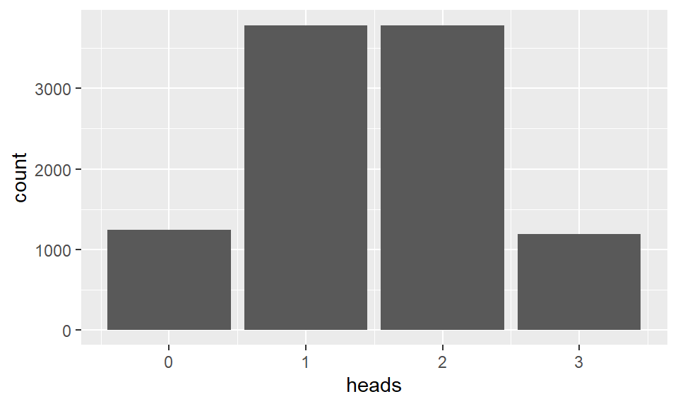

```r
results %>%
  gf_bar(~heads)
```

Finally we can estimate the probability of exactly 2 girls. We need the `tidyverse` library.

```r
library(tidyverse)
```

```r
results %>%
  filter(heads==2) %>%
  summarize(prob=n()/10000)
```

```
##     prob
## 1 0.3782
```

Not a bad estimate of the exact probability.

Let’s now use an example of cards to simulate some probabilities. As well as counting. The file `Cards.csv` contains the data for cards from a 52 card deck. Let’s read it in and summarize.

```r
Cards <- read_csv("data/Cards.csv")
inspect(Cards)
```

```
##
## categorical variables:
##   name     class levels  n missing
## 1 rank character     13 52       0
## 2 suit character      4 52       0
##                                    distribution
## 1 10 (7.7%), 2 (7.7%), 3 (7.7%) ...
## 2 Club (25%), Diamond (25%) ...
##
## quantitative variables:
##    name   class        min         Q1     median         Q3        max
## 1 probs numeric 0.01923077 0.01923077 0.01923077 0.01923077 0.01923077
##         mean sd  n missing
## 1 0.01923077  0 52       0
```

We can see 4 suits, and 13 ranks, the value on the face of the card.

> *Example*:  
> Suppose we draw one card out of a standard deck. Let $A$ be the event that we draw a Club. Let $B$ be the event that we draw a 10 or a face card (Jack, Queen, King or Ace). We can use `R` to define these events and find probabilities.

Let’s find all the Clubs.

```r
Cards %>%
  filter(suit == "Club") %>%
  select(rank,suit)
```

```
## # A tibble: 13 x 2
##    rank  suit
##    <chr> <chr>
##  1 2     Club
##  2 3     Club
##  3 4     Club
##  4 5     Club
##  5 6     Club
##  6 7     Club
##  7 8     Club
##  8 9     Club
##  9 10    Club
## 10 J     Club
## 11 Q     Club
## 12 K     Club
## 13 A     Club
```

So just by counting, we find the probability of drawing a Club is $\frac{13}{52}$ or 0.25.

We can do this by simulation, this is over kill but gets the idea of simulation across.

Remember, ask what do we want `R` to do and what does `R` need to do this?

```r
results <- do(10000)*sample(Cards,1)
head(results)
```

```
## # A tibble: 6 x 6
##   rank  suit   probs orig.id  .row .index
##   <chr> <chr>  <dbl> <chr>   <int>  <dbl>
## 1 9     Spade 0.0192 47          1      1
## 2 5     Club  0.0192 4           1      2
## 3 5     Spade 0.0192 43          1      3
## 4 7     Heart 0.0192 32          1      4
## 5 4     Club  0.0192 3           1      5
## 6 A     Spade 0.0192 52          1      6
```

```r
results %>%
  filter(suit == "Club") %>%
  summarize(prob=n()/10000)
```

```
## # A tibble: 1 x 1
##    prob
##   <dbl>
## 1 0.243
```

Now let’s count the number of outcomes in $B$.

```r
Cards %>%
  filter(rank %in% c(10, "J", "Q", "K", "A")) %>%
  select(rank,suit)
```

```
## # A tibble: 20 x 2
##    rank  suit
##    <chr> <chr>
##  1 10    Club
##  2 J     Club
##  3 Q     Club
##  4 K     Club
##  5 A     Club
##  6 10    Diamond
##  7 J     Diamond
##  8 Q     Diamond
##  9 K     Diamond
## 10 A     Diamond
## 11 10    Heart
## 12 J     Heart
## 13 Q     Heart
## 14 K     Heart
## 15 A     Heart
## 16 10    Spade
## 17 J     Spade
## 18 Q     Spade
## 19 K     Spade
## 20 A     Spade
```

So just by counting, we find the probability of drawing a 10 or greater is $\frac{20}{52}$ or 0.3846154.

> **Exercise**:  
> Using simulation to estimate the probability of 10 or higher.

```r
results <- do(10000)*sample(Cards,1)
head(results)
```

```
## # A tibble: 6 x 6
##   rank  suit   probs orig.id  .row .index
##   <chr> <chr>  <dbl> <chr>   <int>  <dbl>
## 1 10    Heart 0.0192 35          1      1
## 2 6     Heart 0.0192 31          1      2
## 3 8     Spade 0.0192 46          1      3
## 4 J     Heart 0.0192 36          1      4
## 5 Q     Spade 0.0192 50          1      5
## 6 10    Club  0.0192 9           1      6
```

```r
results %>%
  filter(rank %in% c(10, "J", "Q", "K", "A")) %>%
  summarize(prob=n()/10000)
```

```
## # A tibble: 1 x 1
##    prob
##   <dbl>
## 1 0.389
```

Notice that this code is not robust to change the number of simulations. If we change from 10000, then we have to change the denominator in the `summarize()` function. We can change this by using `mutate` instead of `filter`.

```r
results %>%
  mutate(face=rank %in% c(10, "J", "Q", "K", "A"))%>%
  summarize(prob=mean(face))
```

```
## # A tibble: 1 x 1
##    prob
##   <dbl>
## 1 0.389
```

Next, let’s find a card that is 10 or greater **and** a club.

```r
Cards %>%
  filter(rank %in% c(10, "J", "Q", "K", "A"),suit=="Club") %>%
  select(rank,suit)
```

```
## # A tibble: 5 x 2
##   rank  suit
##   <chr> <chr>
## 1 10    Club
## 2 J     Club
## 3 Q     Club
## 4 K     Club
## 5 A     Club
```

We find the probability of drawing a 10 or greater club is $\frac{5}{52}$ or 0.0961538.

> **Exercise**:  
> Simulate drawing one card and estimate the probability of a club that is 10 or greater.

```r
results %>%
  mutate(face=(rank %in% c(10, "J", "Q", "K", "A"))&(suit=="Club"))%>%
  summarize(prob=mean(face))
```

```
## # A tibble: 1 x 1
##     prob
##    <dbl>
## 1 0.0963
```

## Final Note

It may be more interesting to us to explore various events upon drawing 5 cards from a standard deck. Each draw of 5 cards is equally likely, so in order to find the probability of a flush (5 cards of the same suit), we could simply list all the possible flushes and compare that to the sample space. Because of the large number of possible outcomes, this becomes difficult. Next time, we will talk about counting rules that help us solve these problems analytically. To do this with a simulation is also a little tricky but in the case study we put many of these ideas forward.